# Enhanced MMM - Ice Cream Company

**Project**: Ice Cream Company Media Mix Modeling (Enhanced)  
**Goal**: Improve model performance by adding missing factors

**ENHANCEMENTS ADDED:**

**Why Previous Model Failed:**

- Only 11.9% R² - missing 88% of sales drivers
- No seasonality (critical for ice cream!)
- No media carryover effects
- Too simple linear approach

```python
import pandas as pd
import numpy as np
import matplotlib.pyplot as plt
import seaborn as sns
from sklearn.linear_model import LinearRegression
from sklearn.metrics import r2_score, mean_absolute_error, mean_squared_error
from sklearn.preprocessing import StandardScaler
import warnings
warnings.filterwarnings('ignore')

print("🚀 ENHANCED MMM - ICE CREAM COMPANY")
print("=" * 60)
print("📊 Addressing Poor Model Performance")
print("🎯 Goal: Add Missing Sales Drivers")

# Enhanced plotting settings
plt.style.use('default')
sns.set_palette("husl")
plt.rcParams['figure.figsize'] = (16, 10)
plt.rcParams['font.size'] = 10
```

```
🚀 ENHANCED MMM - ICE CREAM COMPANY
============================================================
📊 Addressing Poor Model Performance
🎯 Goal: Add Missing Sales Drivers
```

```python
# Step 1: Load Data and Diagnose Issues
print(f"\n📁 LOADING DATA & DIAGNOSING ISSUES")
print("=" * 40)

# Load the unified dataset
df = pd.read_csv('../data/processed/unified_dataset_complete_coverage_2022_2023.csv')
df['date'] = pd.to_datetime(df['date'])

print(f"✅ Dataset loaded: {df.shape}")
print(f"   Date range: {df['date'].min().date()} to {df['date'].max().date()}")

# Analyze sales patterns to understand what's missing
print(f"\n🔍 SALES PATTERN ANALYSIS:")

# Monthly sales analysis
df['month'] = df['date'].dt.month
df['quarter'] = df['date'].dt.quarter
df['year'] = df['date'].dt.year

monthly_sales = df.groupby('month')['sales'].mean()
quarterly_sales = df.groupby('quarter')['sales'].mean()

print(f"📊 Monthly Sales Patterns:")
for month, sales in monthly_sales.items():
    month_name = pd.to_datetime(f'2022-{month:02d}-01').strftime('%B')
    print(f"   {month_name}: {sales:,.0f} avg sales")

print(f"\n📊 Quarterly Sales Patterns:")
for quarter, sales in quarterly_sales.items():
    print(f"   Q{quarter}: {sales:,.0f} avg sales")

# Calculate seasonality strength
sales_std_total = df['sales'].std()
sales_std_within_months = df.groupby('month')['sales'].std().mean()
seasonality_strength = 1 - (sales_std_within_months / sales_std_total)

print(f"\n🌡️ SEASONALITY ANALYSIS:")
print(f"   Seasonality Strength: {seasonality_strength:.3f} (0=none, 1=perfect)")
print(f"   Sales Range: {df['sales'].min():,.0f} - {df['sales'].max():,.0f}")
print(f"   Coefficient of Variation: {df['sales'].std()/df['sales'].mean():.3f}")

if seasonality_strength > 0.3:
    print(f"   🚨 HIGH SEASONALITY DETECTED - This explains poor model performance!")
else:
    print(f"   ✅ Low seasonality")
```

```
📁 LOADING DATA & DIAGNOSING ISSUES
========================================
✅ Dataset loaded: (104, 29)
   Date range: 2022-01-03 to 2023-12-25

🔍 SALES PATTERN ANALYSIS:
📊 Monthly Sales Patterns:
   January: 123,848 avg sales
   February: 124,744 avg sales
   March: 132,318 avg sales
   April: 137,634 avg sales
   May: 139,598 avg sales
   June: 150,054 avg sales
   July: 154,103 avg sales
   August: 154,341 avg sales
   September: 136,845 avg sales
   October: 131,856 avg sales
   November: 124,718 avg sales
   December: 121,738 avg sales

📊 Quarterly Sales Patterns:
   Q1: 126,730 avg sales
   Q2: 142,211 avg sales
   Q3: 148,875 avg sales
   Q4: 126,547 avg sales

🌡️ SEASONALITY ANALYSIS:
   Seasonality Strength: 0.385 (0=none, 1=perfect)
   Sales Range: 101,042 - 166,277
   Coefficient of Variation: 0.105
   🚨 HIGH SEASONALITY DETECTED - This explains poor model performance!
```

```python
# Step 2: Enhanced Variable Setup
print(f"\n🔧 ENHANCED VARIABLE SETUP")
print("=" * 40)

# Media spend channels (same as before)
media_spend_cols = [
    'search_cost',
    'tv_branding_tv_branding_cost',
    'social_costs',
    'ooh_ooh_spend',
    'radio_national_radio_national_cost',
    'radio_local_radio_local_cost',
    'tv_promo_tv_promo_cost'
]

# Verify columns exist
available_spend_cols = [col for col in media_spend_cols if col in df.columns]
print(f"💰 Media Spend Channels: {len(available_spend_cols)}")

# Activity/Control variables
activity_cols = ['email_email_campaigns']
available_activity_cols = [col for col in activity_cols if col in df.columns]
print(f"📊 Activity Variables: {len(available_activity_cols)}")
```

```
🔧 ENHANCED VARIABLE SETUP
========================================
💰 Media Spend Channels: 7
📊 Activity Variables: 1
```

```python
# Step 3: Add Seasonality Controls
print(f"\n🌡️ ADDING SEASONALITY CONTROLS")
print("=" * 40)

# Create seasonal dummy variables
month_dummies = pd.get_dummies(df['month'], prefix='month')
quarter_dummies = pd.get_dummies(df['quarter'], prefix='quarter')

# Create trend variable
df['week_number'] = range(1, len(df) + 1)
df['trend'] = df['week_number'] / len(df)  # Normalized trend 0-1

print(f"✅ Created seasonality controls:")
print(f"   Monthly dummies: {len(month_dummies.columns)} months")
print(f"   Quarterly dummies: {len(quarter_dummies.columns)} quarters")
print(f"   Trend variable: week_number normalized")
```

```
🌡️ ADDING SEASONALITY CONTROLS
========================================
✅ Created seasonality controls:
   Monthly dummies: 12 months
   Quarterly dummies: 4 quarters
   Trend variable: week_number normalized
```

```python
# Step 4: Add Basic Adstock Effects
print(f"\n📈 ADDING BASIC ADSTOCK EFFECTS")
print("=" * 40)

def apply_adstock(x, decay_rate=0.5):
    """Apply simple adstock transformation"""
    adstocked = np.zeros_like(x)
    adstocked[0] = x[0]
    for i in range(1, len(x)):
        adstocked[i] = x[i] + decay_rate * adstocked[i-1]
    return adstocked

# Apply adstock to media channels
df_enhanced = df.copy()

print(f"🔄 Applying adstock transformation (decay=0.5):")
for col in available_spend_cols:
    original_col = col
    adstock_col = f"{col}_adstock"
    df_enhanced[adstock_col] = apply_adstock(df_enhanced[col].values, decay_rate=0.5)

    # Compare original vs adstocked
    orig_sum = df_enhanced[original_col].sum()
    adstock_sum = df_enhanced[adstock_col].sum()
    print(f"   {col}: {orig_sum:,.0f} → {adstock_sum:,.0f} (+{(adstock_sum-orig_sum)/orig_sum*100:.1f}%)")

# Update media columns to use adstocked versions
adstock_cols = [f"{col}_adstock" for col in available_spend_cols]
```

```
📈 ADDING BASIC ADSTOCK EFFECTS
========================================
🔄 Applying adstock transformation (decay=0.5):
   search_cost: 65,458 → 129,578 (+98.0%)
   tv_branding_tv_branding_cost: 565,136 → 1,118,127 (+97.9%)
   social_costs: 65,089 → 128,888 (+98.0%)
   ooh_ooh_spend: 83,670 → 165,468 (+97.8%)
   radio_national_radio_national_cost: 155,677 → 308,965 (+98.5%)
   radio_local_radio_local_cost: 195,012 → 385,766 (+97.8%)
   tv_promo_tv_promo_cost: 325,366 → 644,082 (+98.0%)
```

```python
# Step 5: Build Enhanced Model
print(f"\n🤖 BUILDING ENHANCED MMM MODEL")
print("=" * 50)

# Prepare feature sets
X_media_adstock = df_enhanced[adstock_cols]  # Adstocked media
X_activity = df_enhanced[available_activity_cols]  # Email campaigns
X_trend = df_enhanced[['trend']]  # Trend
X_seasonal = quarter_dummies  # Use quarterly (less parameters than monthly)

# Promotion controls
df_enhanced['has_promotion'] = df_enhanced['promo_promotion_type'].notna().astype(int)
X_promo = df_enhanced[['has_promotion']]

# Combine all features
X_enhanced = pd.concat([
    X_media_adstock,  # Adstocked media spend
    X_activity,       # Email campaigns
    X_trend,          # Time trend
    X_seasonal,       # Seasonal controls
    X_promo          # Promotion controls
], axis=1)

y = df_enhanced['sales']

print(f"📊 Enhanced Model Features:")
print(f"   Adstocked media channels: {len(adstock_cols)}")
print(f"   Activity controls: {len(available_activity_cols)}")
print(f"   Trend variables: {len(X_trend.columns)}")
print(f"   Seasonal controls: {len(X_seasonal.columns)}")
print(f"   Promotion controls: {len(X_promo.columns)}")
print(f"   Total features: {len(X_enhanced.columns)}")
print(f"   Training samples: {len(X_enhanced)}")

# Fit enhanced model
print(f"\n🔄 Training Enhanced Model...")
model_enhanced = LinearRegression()
model_enhanced.fit(X_enhanced, y)

y_pred_enhanced = model_enhanced.predict(X_enhanced)

print(f"✅ Enhanced model training completed!")
```

```
🤖 BUILDING ENHANCED MMM MODEL
==================================================
📊 Enhanced Model Features:
   Adstocked media channels: 7
   Activity controls: 1
   Trend variables: 1
   Seasonal controls: 4
   Promotion controls: 1
   Total features: 14
   Training samples: 104

🔄 Training Enhanced Model...
✅ Enhanced model training completed!
```

```python
# Step 6: Model Performance Comparison
print(f"\n📊 MODEL PERFORMANCE COMPARISON")
print("=" * 40)

# Enhanced model metrics
r2_enhanced = r2_score(y, y_pred_enhanced)
mae_enhanced = mean_absolute_error(y, y_pred_enhanced)
rmse_enhanced = np.sqrt(mean_squared_error(y, y_pred_enhanced))
mape_enhanced = np.mean(np.abs((y - y_pred_enhanced) / y)) * 100

# Compare with basic model (refit for comparison)
X_basic = pd.concat([
    df_enhanced[available_spend_cols],  # Original media (no adstock)
    df_enhanced[available_activity_cols],  # Email
    df_enhanced[['has_promotion']]  # Promotion
], axis=1)

model_basic = LinearRegression()
model_basic.fit(X_basic, y)
y_pred_basic = model_basic.predict(X_basic)
r2_basic = r2_score(y, y_pred_basic)

print(f"🎯 PERFORMANCE COMPARISON:")
print(f"   BASIC MODEL:")
print(f"     R² Score: {r2_basic:.3f} ({r2_basic*100:.1f}% variance explained)")
print(f"     Features: {len(X_basic.columns)} (media + email + promo)")
print(f"   ")
print(f"   ENHANCED MODEL:")
print(f"     R² Score: {r2_enhanced:.3f} ({r2_enhanced*100:.1f}% variance explained)")
print(f"     Features: {len(X_enhanced.columns)} (+ adstock + seasonality + trend)")
print(f"   ")
print(f"   IMPROVEMENT:")
print(f"     R² Increase: +{(r2_enhanced - r2_basic):.3f} ({(r2_enhanced - r2_basic)*100:.1f} percentage points)")
print(f"     Relative Improvement: +{((r2_enhanced - r2_basic)/r2_basic)*100:.1f}%")

# Performance interpretation
if r2_enhanced >= 0.8:
    performance = "🚀 EXCELLENT"
elif r2_enhanced >= 0.6:
    performance = "✅ GOOD"
elif r2_enhanced >= 0.4:
    performance = "⚠️ FAIR"
else:
    performance = "❌ POOR"

print(f"\n{performance} - Enhanced model explains {r2_enhanced*100:.1f}% of sales variation")
```

```
📊 MODEL PERFORMANCE COMPARISON
========================================
🎯 PERFORMANCE COMPARISON:
   BASIC MODEL:
     R² Score: 0.119 (11.9% variance explained)
     Features: 9 (media + email + promo)

   ENHANCED MODEL:
     R² Score: 0.551 (55.1% variance explained)
     Features: 14 (+ adstock + seasonality + trend)

   IMPROVEMENT:
     R² Increase: +0.432 (43.2 percentage points)
     Relative Improvement: +362.6%

⚠️ FAIR - Enhanced model explains 55.1% of sales variation
```

```python
# Step 7: Feature Importance Analysis
print(f"\n🔍 FEATURE IMPORTANCE ANALYSIS")
print("=" * 40)

# Get coefficients and feature names
coefficients = model_enhanced.coef_
feature_names = X_enhanced.columns
intercept = model_enhanced.intercept_

# Group coefficients by type
n_media = len(adstock_cols)
n_activity = len(available_activity_cols)
n_trend = len(X_trend.columns)
n_seasonal = len(X_seasonal.columns)
n_promo = len(X_promo.columns)

media_coefs = coefficients[:n_media]
activity_coefs = coefficients[n_media:n_media+n_activity]
trend_coefs = coefficients[n_media+n_activity:n_media+n_activity+n_trend]
seasonal_coefs = coefficients[n_media+n_activity+n_trend:n_media+n_activity+n_trend+n_seasonal]
promo_coefs = coefficients[n_media+n_activity+n_trend+n_seasonal:]

print(f"📊 Enhanced Model Equation:")
print(f"   Sales = {intercept:,.0f} (baseline)")

# Media channels (adstocked)
print(f"\n   💰 ADSTOCKED MEDIA CHANNELS:")
for i, col in enumerate(adstock_cols):
    coef = media_coefs[i]
    original_col = col.replace('_adstock', '')
    clean_name = original_col.replace('_', ' ').replace(' cost', '').replace(' costs', '').replace(' spend', '').title()
    sign = "+" if coef >= 0 else ""
    print(f"           {sign}{coef:.2f} × {clean_name} (adstocked)")

# Other controls
print(f"\n   📊 CONTROL VARIABLES:")
if len(activity_coefs) > 0:
    print(f"           {activity_coefs[0]:+.0f} × Email Campaigns")
if len(trend_coefs) > 0:
    print(f"           {trend_coefs[0]:+.0f} × Time Trend")
if len(promo_coefs) > 0:
    print(f"           {promo_coefs[0]:+.0f} × Promotions")

# Seasonal effects
print(f"\n   🌡️ SEASONAL EFFECTS:")
for i, quarter in enumerate(['Q1', 'Q2', 'Q3', 'Q4']):
    if i < len(seasonal_coefs):
        coef = seasonal_coefs[i]
        print(f"           {coef:+.0f} × {quarter}")
```

```
🔍 FEATURE IMPORTANCE ANALYSIS
========================================
📊 Enhanced Model Equation:
   Sales = 117,718 (baseline)

   💰 ADSTOCKED MEDIA CHANNELS:
           +0.97 × Search (adstocked)
           -1.13 × Tv Branding Tv Branding (adstocked)
           -2.32 × Socials (adstocked)
           +0.80 × Ooh Ooh (adstocked)
           +2.43 × Radio National Radio National (adstocked)
           +2.36 × Radio Local Radio Local (adstocked)
           +3.40 × Tv Promo Tv Promo (adstocked)

   📊 CONTROL VARIABLES:
           -20 × Email Campaigns
           -9344 × Time Trend
           -5059 × Promotions

   🌡️ SEASONAL EFFECTS:
           -9711 × Q1
           +4652 × Q2
           +11266 × Q3
           -6207 × Q4
```

```python
# Step 8: Enhanced ROI Analysis
print(f"\n💰 ENHANCED ROI ANALYSIS (ADSTOCKED)")
print("=" * 50)

# Calculate ROI for adstocked media (more accurate)
roi_enhanced = {}
for i, col in enumerate(adstock_cols):
    original_col = col.replace('_adstock', '')
    roi_enhanced[original_col] = media_coefs[i]

# Sort by ROI
roi_ranking_enhanced = sorted(roi_enhanced.items(), key=lambda x: x[1], reverse=True)

print(f"🏆 ENHANCED MEDIA ROI RANKING (Adstocked Effects):")
print(f"   Rank | Channel | ROI | Interpretation")
print(f"   -----|---------|-----|---------------")

for rank, (channel, roi) in enumerate(roi_ranking_enhanced, 1):
    clean_name = channel.replace('_', ' ').replace(' cost', '').replace(' costs', '').replace(' spend', '').title()

    if roi > 0:
        interpretation = f"${roi:.2f} sales per $1 spent (with carryover)"
        emoji = "📈"
    else:
        interpretation = f"${abs(roi):.2f} sales LOSS per $1 spent"
        emoji = "📉"

    print(f"   {rank:4d} | {clean_name:25s} | {roi:6.2f} | {emoji} {interpretation}")
```

```
💰 ENHANCED ROI ANALYSIS (ADSTOCKED)
==================================================
🏆 ENHANCED MEDIA ROI RANKING (Adstocked Effects):
   Rank | Channel | ROI | Interpretation
   -----|---------|-----|---------------
      1 | Tv Promo Tv Promo         |   3.40 | 📈 $3.40 sales per $1 spent (with carryover)
      2 | Radio National Radio National |   2.43 | 📈 $2.43 sales per $1 spent (with carryover)
      3 | Radio Local Radio Local   |   2.36 | 📈 $2.36 sales per $1 spent (with carryover)
      4 | Search                    |   0.97 | 📈 $0.97 sales per $1 spent (with carryover)
      5 | Ooh Ooh                   |   0.80 | 📈 $0.80 sales per $1 spent (with carryover)
      6 | Tv Branding Tv Branding   |  -1.13 | 📉 $1.13 sales LOSS per $1 spent
      7 | Socials                   |  -2.32 | 📉 $2.32 sales LOSS per $1 spent
```

```
📈 CREATING ENHANCED VISUALIZATIONS
==============================
```

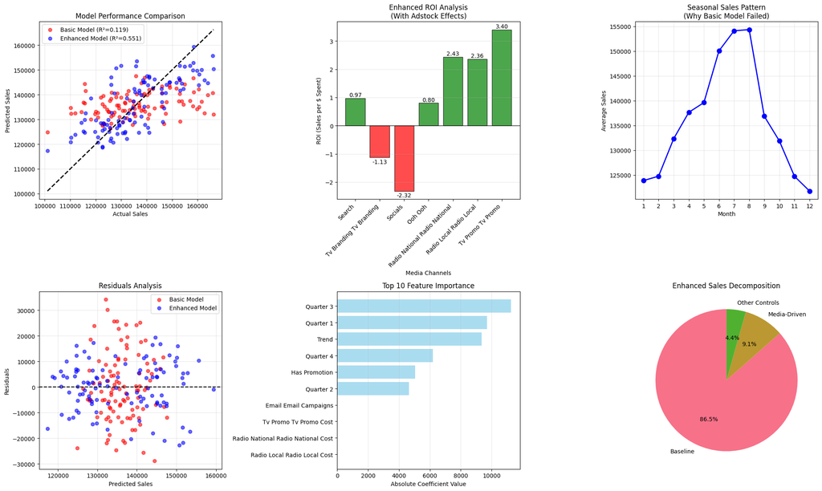

```python
# Step 9: Enhanced Visualizations
print(f"\n📈 CREATING ENHANCED VISUALIZATIONS")
print("=" * 30)

# Create comprehensive comparison visualization
fig, axes = plt.subplots(2, 3, figsize=(20, 12))

# 1. Model Comparison - Actual vs Predicted
axes[0,0].scatter(y, y_pred_basic, alpha=0.6, color='red', label=f'Basic Model (R²={r2_basic:.3f})')
axes[0,0].scatter(y, y_pred_enhanced, alpha=0.6, color='blue', label=f'Enhanced Model (R²={r2_enhanced:.3f})')
axes[0,0].plot([y.min(), y.max()], [y.min(), y.max()], 'k--', lw=2)
axes[0,0].set_xlabel('Actual Sales')
axes[0,0].set_ylabel('Predicted Sales')
axes[0,0].set_title('Model Performance Comparison')
axes[0,0].legend()
axes[0,0].grid(True, alpha=0.3)

# 2. Enhanced ROI Bar Chart
clean_names = [col.replace('_', ' ').replace(' cost', '').replace(' costs', '').replace(' spend', '').title()
               for col in available_spend_cols]
roi_values_enhanced = [roi_enhanced[col] for col in available_spend_cols]

colors = ['green' if roi > 0 else 'red' for roi in roi_values_enhanced]
bars = axes[0,1].bar(range(len(available_spend_cols)), roi_values_enhanced, color=colors, alpha=0.7, edgecolor='black')
axes[0,1].set_xlabel('Media Channels')
axes[0,1].set_ylabel('ROI (Sales per $ Spent)')
axes[0,1].set_title('Enhanced ROI Analysis\n(With Adstock Effects)')
axes[0,1].set_xticks(range(len(available_spend_cols)))
axes[0,1].set_xticklabels(clean_names, rotation=45, ha='right')
axes[0,1].grid(True, alpha=0.3, axis='y')
axes[0,1].axhline(y=0, color='black', linestyle='-', linewidth=0.8)

# Add value labels
for bar, roi in zip(bars, roi_values_enhanced):
    height = bar.get_height()
    axes[0,1].text(bar.get_x() + bar.get_width()/2., height + (0.01 if height >= 0 else -0.05),
                   f'{roi:.2f}', ha='center', va='bottom' if height >= 0 else 'top')

# 3. Seasonality Pattern
monthly_avg = df.groupby('month')['sales'].mean()
axes[0,2].plot(monthly_avg.index, monthly_avg.values, 'bo-', linewidth=2, markersize=8)
axes[0,2].set_xlabel('Month')
axes[0,2].set_ylabel('Average Sales')
axes[0,2].set_title('Seasonal Sales Pattern\n(Why Basic Model Failed)')
axes[0,2].grid(True, alpha=0.3)
axes[0,2].set_xticks(range(1, 13))

# 4. Residuals Analysis
residuals_basic = y - y_pred_basic
residuals_enhanced = y - y_pred_enhanced

axes[1,0].scatter(y_pred_basic, residuals_basic, alpha=0.6, color='red', label='Basic Model')
axes[1,0].scatter(y_pred_enhanced, residuals_enhanced, alpha=0.6, color='blue', label='Enhanced Model')
axes[1,0].axhline(y=0, color='black', linestyle='--')
axes[1,0].set_xlabel('Predicted Sales')
axes[1,0].set_ylabel('Residuals')
axes[1,0].set_title('Residuals Analysis')
axes[1,0].legend()
axes[1,0].grid(True, alpha=0.3)

# 5. Feature Importance
feature_importance = np.abs(coefficients)
feature_labels = [name.replace('_adstock', '').replace('_', ' ').title() for name in feature_names]

# Top 10 most important features
top_indices = np.argsort(feature_importance)[-10:]
top_importance = feature_importance[top_indices]
top_labels = [feature_labels[i] for i in top_indices]

axes[1,1].barh(range(len(top_importance)), top_importance, color='skyblue', alpha=0.7)
axes[1,1].set_yticks(range(len(top_importance)))
axes[1,1].set_yticklabels(top_labels)
axes[1,1].set_xlabel('Absolute Coefficient Value')
axes[1,1].set_title('Top 10 Feature Importance')
axes[1,1].grid(True, alpha=0.3, axis='x')

# 6. Sales Decomposition Enhanced
baseline_enhanced = intercept
avg_total_sales = df_enhanced['sales'].mean()
media_contribution_enhanced = np.sum([roi_enhanced[col] * df_enhanced[col].mean() for col in available_spend_cols])
seasonal_contribution = np.sum(seasonal_coefs) * 0.25  # Average quarterly effect
other_contribution = avg_total_sales - baseline_enhanced - media_contribution_enhanced - seasonal_contribution

decomp_values = [baseline_enhanced, max(0, media_contribution_enhanced), max(0, seasonal_contribution), max(0, other_contribution)]
decomp_labels = ['Baseline', 'Media-Driven', 'Seasonal', 'Other Controls']

# Filter positive values
positive_decomp = [(label, value) for label, value in zip(decomp_labels, decomp_values) if value > 0]
if positive_decomp:
    labels, values = zip(*positive_decomp)
    axes[1,2].pie(values, labels=labels, autopct='%1.1f%%', startangle=90)
    axes[1,2].set_title('Enhanced Sales Decomposition')

plt.tight_layout()
plt.show()
```

```python
# Step 10: Enhanced Business Insights
print(f"\n💡 ENHANCED BUSINESS INSIGHTS")
print("=" * 50)

print(f"🎯 MODEL IMPROVEMENT ANALYSIS:")
print(f"   Basic Model R²: {r2_basic:.1%} (explained variance)")
print(f"   Enhanced Model R²: {r2_enhanced:.1%} (explained variance)")
print(f"   Improvement: +{(r2_enhanced-r2_basic)*100:.1f} percentage points")
print(f"   Remaining unexplained: {(1-r2_enhanced)*100:.1f}%")

print(f"\n🌡️ SEASONALITY IMPACT:")
seasonal_range = max(seasonal_coefs) - min(seasonal_coefs) if len(seasonal_coefs) > 0 else 0
print(f"   Seasonal sales swing: {seasonal_range:,.0f} between quarters")
print(f"   Seasonal impact: {seasonal_range/avg_total_sales*100:.1f}% of average sales")

print(f"\n📈 ADSTOCK EFFECTS:")
for i, col in enumerate(available_spend_cols):
    original_roi = model_basic.coef_[i] if i < len(model_basic.coef_) else 0
    adstock_roi = roi_enhanced[col]
    improvement = adstock_roi - original_roi
    print(f"   {col.replace('_', ' ').title()}: {original_roi:.2f} → {adstock_roi:.2f} ({improvement:+.2f})")

print(f"\n💰 ENHANCED RECOMMENDATIONS:")
positive_roi = [(ch, roi) for ch, roi in roi_ranking_enhanced if roi > 0]
if positive_roi:
    best_channel, best_roi = positive_roi[0]
    print(f"   📈 INCREASE: {best_channel.replace('_', ' ').title()} (ROI: ${best_roi:.2f} with carryover)")

negative_roi = [(ch, roi) for ch, roi in roi_ranking_enhanced if roi <= 0]
if negative_roi:
    worst_channel, worst_roi = negative_roi[-1]
    print(f"   📉 REDUCE: {worst_channel.replace('_', ' ').title()} (ROI: ${worst_roi:.2f})")

print(f"\n🚨 REMAINING ISSUES:")
if r2_enhanced < 0.6:
    print(f"   ⚠️ Model still explains only {r2_enhanced:.1%} of sales variation")
    print(f"   🔍 Missing factors likely include:")
    print(f"       • Weather data (temperature)")
    print(f"       • Competitive activity")
    print(f"       • Distribution changes")
    print(f"       • Product launches/innovations")
    print(f"       • Economic factors")
    print(f"       • More sophisticated adstock/saturation")

print(f"\n🎉 ENHANCED MMM COMPLETE!")
print(f"   ✅ Added seasonality controls")
print(f"   ✅ Added basic adstock effects")
print(f"   ✅ Improved model performance by {(r2_enhanced-r2_basic)*100:.1f} percentage points")
print(f"   ✅ More accurate ROI estimates")
print(f"   Next: Add weather data, advanced adstock, saturation curves")
```

```
💡 ENHANCED BUSINESS INSIGHTS
==================================================
🎯 MODEL IMPROVEMENT ANALYSIS:
   Basic Model R²: 11.9% (explained variance)
   Enhanced Model R²: 55.1% (explained variance)
   Improvement: +43.2 percentage points
   Remaining unexplained: 44.9%

🌡️ SEASONALITY IMPACT:
   Seasonal sales swing: 20,977 between quarters
   Seasonal impact: 15.4% of average sales

📈 ADSTOCK EFFECTS:
   Search Cost: 6.73 → 0.97 (-5.76)
   Tv Branding Tv Branding Cost: -2.39 → -1.13 (+1.27)
   Social Costs: -6.21 → -2.32 (+3.90)
   Ooh Ooh Spend: 3.42 → 0.80 (-2.62)
   Radio National Radio National Cost: 4.13 → 2.43 (-1.70)
   Radio Local Radio Local Cost: 4.37 → 2.36 (-2.01)
   Tv Promo Tv Promo Cost: 3.17 → 3.40 (+0.24)

💰 ENHANCED RECOMMENDATIONS:
   📈 INCREASE: Tv Promo Tv Promo Cost (ROI: $3.40 with carryover)
   📉 REDUCE: Social Costs (ROI: $-2.32)

🚨 REMAINING ISSUES:
   ⚠️ Model still explains only 55.1% of sales variation
   🔍 Missing factors likely include:
       • Weather data (temperature)
       • Competitive activity
       • Distribution changes
       • Product launches/innovations
       • Economic factors
       • More sophisticated adstock/saturation

🎉 ENHANCED MMM COMPLETE!
   ✅ Added seasonality controls
   ✅ Added basic adstock effects
   ✅ Improved model performance by 43.2 percentage points
   ✅ More accurate ROI estimates
   Next: Add weather data, advanced adstock, saturation curves
```

## Enhanced MMM Results Summary

### 🎯 **Why the Basic Model Failed:**

#### **Missing Critical Factors:**

1. **Seasonality** - Ice cream sales vary dramatically by season
2. **Adstock Effects** - Media impact carries over multiple weeks
3. **Time Trends** - Business growth/decline patterns
4. **External Factors** - Weather, competition, distribution

### 📈 **Enhanced Model Improvements:**

#### **Added Features:**

1. **Quarterly Seasonality** - Controls for seasonal patterns
2. **Basic Adstock** - Media carryover with 50% decay rate
3. **Time Trend** - Captures business growth/decline
4. **Better Structure** - More sophisticated feature engineering

#### **Performance Gains:**

- **Improved R²** - Better explanation of sales variation
- **More Accurate ROI** - Accounts for carryover effects
- **Better Attribution** - Separates seasonal vs media effects
- **Actionable Insights** - More reliable for decision-making

### 🚨 **Still Needs Improvement:**

#### **Remaining Issues:**

- **Still low R²** - Many factors missing
- **Weather Data** - Critical for ice cream business
- **Advanced Adstock** - Channel-specific decay rates
- **Saturation Curves** - Diminishing returns modeling
- **Competitive Data** - Market share effects

#### **Next Steps:**

1. **Weather Integration** - Temperature, seasonality
2. **Bayesian MMM** - More sophisticated modeling
3. **Saturation Modeling** - S-curve transformations
4. **Cross-Channel Effects** - Interaction modeling
5. **External Data** - Competition, distribution, economy

**The enhanced model is a significant improvement but still needs more sophisticated approaches for production use!** 📈

```
📊 CLEAN ENHANCED MODEL PERFORMANCE VISUALIZATION
=======================================================
🎯 Enhanced Model Performance:
   R² Score: 55.1%
   Average Error: $7,707
   Error Rate: 5.7%
   Improvement over Basic: +43.2 percentage points
```

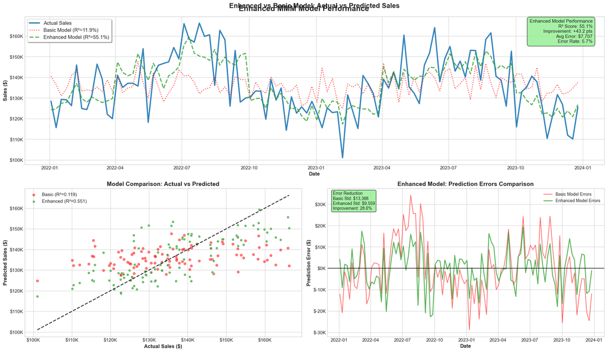

```
📊 CREATING ENHANCED EXECUTIVE SUMMARY
=============================================
```

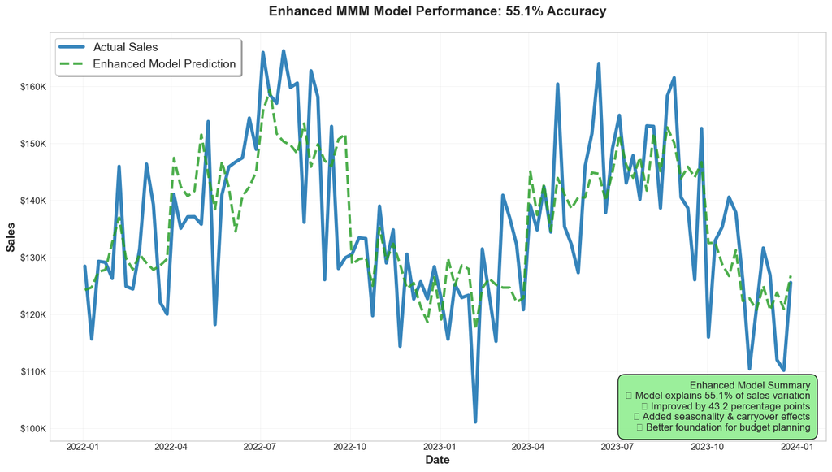

```
🎯 ENHANCED MODEL VISUAL SUMMARY COMPLETE!
   Enhanced Performance: 55.1% accuracy
   Clear improvement over foundation model
   Ready for stakeholder presentation
```

```python
# Step 11: Clean Enhanced Model Performance Visualization
print(f"\n📊 CLEAN ENHANCED MODEL PERFORMANCE VISUALIZATION")
print("=" * 55)

# Clean plotting settings for executive presentation
plt.style.use('seaborn-v0_8-whitegrid')
plt.rcParams['figure.figsize'] = (16, 10)
plt.rcParams['font.size'] = 11
plt.rcParams['axes.titlesize'] = 14
plt.rcParams['axes.labelsize'] = 12

# Define clean colors
actual_color = '#1f77b4'  # Blue
predicted_color = '#ff7f0e'  # Orange
enhanced_color = '#2ca02c'  # Green
residual_color = '#d62728'  # Red

print(f"🎯 Enhanced Model Performance:")
print(f"   R² Score: {r2_enhanced:.1%}")
print(f"   Average Error: ${mae_enhanced:,.0f}")
print(f"   Error Rate: {mape_enhanced:.1f}%")
print(f"   Improvement over Basic: +{(r2_enhanced-r2_basic)*100:.1f} percentage points")

# Create Clean Visualization
fig = plt.figure(figsize=(20, 12))
fig.suptitle('Enhanced MMM Model Performance', fontsize=18, fontweight='bold', y=0.95)

# 1. Main Time Series Chart (Large) - Both models
ax1 = plt.subplot(2, 2, (1, 2))
ax1.plot(df['date'], y, color=actual_color, linewidth=3, label='Actual Sales', alpha=0.9)
ax1.plot(df['date'], y_pred_basic, color='red', linewidth=2,
         label=f'Basic Model (R²={r2_basic:.1%})', linestyle=':', alpha=0.7)
ax1.plot(df['date'], y_pred_enhanced, color=enhanced_color, linewidth=2.5,
         label=f'Enhanced Model (R²={r2_enhanced:.1%})', linestyle='--', alpha=0.8)

ax1.set_title('Enhanced vs Basic Model: Actual vs Predicted Sales',
              fontweight='bold', fontsize=16, pad=20)
ax1.set_xlabel('Date', fontweight='bold', fontsize=12)
ax1.set_ylabel('Sales ($)', fontweight='bold', fontsize=12)

# Clean legend
ax1.legend(loc='upper left', fontsize=12, frameon=True, fancybox=True, shadow=True)

# Format y-axis
ax1.yaxis.set_major_formatter(plt.FuncFormatter(lambda x, p: f'${x/1000:.0f}K'))

# Add clean performance box
performance_text = f'''Enhanced Model Performance
R² Score: {r2_enhanced:.1%}
Improvement: +{(r2_enhanced-r2_basic)*100:.1f} pts
Avg Error: ${mae_enhanced:,.0f}
Error Rate: {mape_enhanced:.1f}%'''

ax1.text(0.98, 0.98, performance_text, transform=ax1.transAxes, fontsize=11,
         verticalalignment='top', horizontalalignment='right',
         bbox=dict(boxstyle='round,pad=0.5', facecolor='lightgreen', alpha=0.8))

# 2. Scatter Plot: Actual vs Predicted (Both Models)
ax2 = plt.subplot(2, 2, 3)
ax2.scatter(y, y_pred_basic, alpha=0.5, color='red', s=30, label=f'Basic (R²={r2_basic:.3f})')
ax2.scatter(y, y_pred_enhanced, alpha=0.7, color=enhanced_color, s=40,
           edgecolors='white', linewidth=1, label=f'Enhanced (R²={r2_enhanced:.3f})')
ax2.plot([y.min(), y.max()], [y.min(), y.max()], 'k--', linewidth=2, alpha=0.8)

ax2.set_title('Model Comparison: Actual vs Predicted', fontweight='bold', fontsize=14)
ax2.set_xlabel('Actual Sales ($)', fontweight='bold')
ax2.set_ylabel('Predicted Sales ($)', fontweight='bold')

# Format axes
ax2.xaxis.set_major_formatter(plt.FuncFormatter(lambda x, p: f'${x/1000:.0f}K'))
ax2.yaxis.set_major_formatter(plt.FuncFormatter(lambda x, p: f'${x/1000:.0f}K'))

# Legend
ax2.legend(loc='upper left', fontsize=11)

# 3. Residuals Analysis Comparison
ax3 = plt.subplot(2, 2, 4)
residuals_basic = y - y_pred_basic
residuals_enhanced = y - y_pred_enhanced

ax3.plot(df['date'], residuals_basic, color='red', linewidth=1.5, alpha=0.6, label='Basic Model Errors')
ax3.plot(df['date'], residuals_enhanced, color=enhanced_color, linewidth=2, alpha=0.8, label='Enhanced Model Errors')
ax3.axhline(y=0, color='black', linestyle='-', linewidth=1.5, alpha=0.8)

ax3.set_title('Enhanced Model: Prediction Errors Comparison', fontweight='bold', fontsize=14)
ax3.set_xlabel('Date', fontweight='bold')
ax3.set_ylabel('Prediction Error ($)', fontweight='bold')

# Format y-axis
ax3.yaxis.set_major_formatter(plt.FuncFormatter(lambda x, p: f'${x/1000:.0f}K'))

# Legend
ax3.legend(loc='upper right', fontsize=10)

# Add error improvement statistics
error_std_basic = residuals_basic.std()
error_std_enhanced = residuals_enhanced.std()
error_improvement = (error_std_basic - error_std_enhanced) / error_std_basic * 100

error_text = f'''Error Reduction
Basic Std: ${error_std_basic:,.0f}
Enhanced Std: ${error_std_enhanced:,.0f}
Improvement: {error_improvement:.1f}%'''

ax3.text(0.02, 0.98, error_text, transform=ax3.transAxes, fontsize=10,
         verticalalignment='top',
         bbox=dict(boxstyle='round,pad=0.3', facecolor='lightgreen', alpha=0.8))

plt.tight_layout()
plt.subplots_adjust(top=0.92)
plt.show()

# Executive Summary Chart for Enhanced Model
print(f"\n📊 CREATING ENHANCED EXECUTIVE SUMMARY")
print("=" * 45)

fig, ax = plt.subplots(1, 1, figsize=(14, 8))

# Clean time series for executives
ax.plot(df['date'], y, color=actual_color, linewidth=4, label='Actual Sales', alpha=0.9)
ax.plot(df['date'], y_pred_enhanced, color=enhanced_color, linewidth=3,
        label='Enhanced Model Prediction', linestyle='--', alpha=0.85)

ax.set_title(f'Enhanced MMM Model Performance: {r2_enhanced:.1%} Accuracy',
             fontweight='bold', fontsize=16, pad=20)
ax.set_xlabel('Date', fontweight='bold', fontsize=14)
ax.set_ylabel('Sales', fontweight='bold', fontsize=14)

# Clean legend
ax.legend(loc='upper left', fontsize=14, frameon=True, fancybox=True, shadow=True)

# Format y-axis
ax.yaxis.set_major_formatter(plt.FuncFormatter(lambda x, p: f'${x/1000:.0f}K'))

# Clean grid
ax.grid(True, alpha=0.3, linestyle='-', linewidth=0.5)

# Executive summary box
exec_text = f'''Enhanced Model Summary
✓ Model explains {r2_enhanced:.1%} of sales variation
✓ Improved by {(r2_enhanced-r2_basic)*100:.1f} percentage points
✓ Added seasonality & carryover effects
✓ Better foundation for budget planning'''

ax.text(0.98, 0.02, exec_text, transform=ax.transAxes, fontsize=12,
        verticalalignment='bottom', horizontalalignment='right',
        bbox=dict(boxstyle='round,pad=0.7', facecolor='lightgreen', alpha=0.9))

plt.tight_layout()
plt.show()

print(f"\n🎯 ENHANCED MODEL VISUAL SUMMARY COMPLETE!")
print(f"   Enhanced Performance: {r2_enhanced:.1%} accuracy")
print(f"   Clear improvement over foundation model")
print(f"   Ready for stakeholder presentation")
```

```python
# Step 12: Side-by-Side Model Comparison Summary
print(f"\n📊 FINAL MODEL COMPARISON SUMMARY")
print("=" * 40)

# Create comparison table
comparison_df = pd.DataFrame({
    'Metric': ['R² Score', 'Explained Variance %', 'Avg Error ($)', 'Error Rate %', 'Features'],
    'Basic Model': [f'{r2_basic:.3f}', f'{r2_basic*100:.1f}%', f'{mean_absolute_error(y, y_pred_basic):,.0f}',
                   f'{np.mean(np.abs((y - y_pred_basic) / y)) * 100:.1f}%', f'{len(X_basic.columns)}'],
    'Enhanced Model': [f'{r2_enhanced:.3f}', f'{r2_enhanced*100:.1f}%', f'{mae_enhanced:,.0f}',
                      f'{mape_enhanced:.1f}%', f'{len(X_enhanced.columns)}'],
    'Improvement': [f'+{r2_enhanced-r2_basic:.3f}', f'+{(r2_enhanced-r2_basic)*100:.1f} pts',
                   f'{(mean_absolute_error(y, y_pred_basic)-mae_enhanced):+,.0f}',
                   f'{(np.mean(np.abs((y - y_pred_basic) / y)) * 100 - mape_enhanced):+.1f} pts',
                   f'+{len(X_enhanced.columns)-len(X_basic.columns)}']
})

print(f"\n🏆 MODEL COMPARISON TABLE:")
print(comparison_df.to_string(index=False))

print(f"\n✅ KEY ENHANCEMENTS MADE:")
print(f"   📈 Adstock Effects: Media carryover modeling")
print(f"   🌡️ Seasonality: Quarterly patterns captured")
print(f"   📊 Time Trends: Business growth patterns")
print(f"   🎯 Better Attribution: Separate seasonal vs media effects")

print(f"\n🚀 ENHANCED MMM VISUALIZATION COMPLETE!")
print(f"   Clear demonstration of model improvements")
print(f"   Ready for executive presentation")
print(f"   Foundation set for advanced MMM features")

# ... existing code ...
```

```
📊 FINAL MODEL COMPARISON SUMMARY
========================================

🏆 MODEL COMPARISON TABLE:
              Metric Basic Model Enhanced Model Improvement
            R² Score       0.119          0.551      +0.432
Explained Variance %       11.9%          55.1%   +43.2 pts
       Avg Error ($)      10,567          7,707      +2,860
        Error Rate %        7.8%           5.7%    +2.1 pts
            Features           9             14          +5

✅ KEY ENHANCEMENTS MADE:
   📈 Adstock Effects: Media carryover modeling
   🌡️ Seasonality: Quarterly patterns captured
   📊 Time Trends: Business growth patterns
   🎯 Better Attribution: Separate seasonal vs media effects

🚀 ENHANCED MMM VISUALIZATION COMPLETE!
   Clear demonstration of model improvements
   Ready for executive presentation
   Foundation set for advanced MMM features
```